# Practical Machine Learning Project

Mohammed Ait-Oufkir

10 September 2018

## Executive Summary

Collecting large amount data about personal activity is now accessible due to the availabilty of devices such as *Jawbone Up*, *Nike FuelBand*, and *Fitbit*. The analysis of this data opens new perspective in understanding the patterns in human behaviour, health assessment and activities quantification.

The goal of this project is to analyse and predict the qualitative activity recognition (the way subjects perform Unilateral Dumbbell Biceps Curl exercice). The quality of the activity is captured in the depenent variable “classe” which is split in the five following classes:

- Class A: Exactly according to the specification
- Class B: Throwing the elbows to the front
- Class C: Lifting the dumbbell only halfway
- Class D: Lowering the dumbbell only halfway
- Class E: Throwing the hips to the front

Two models (Decision Tree and Random Forest) are explored and during the analysis a rational behind model choice will be explained.

# Note on Reproduceablity

If not installed the following packages are needed

```r
library(kableExtra)
library(caret)
library(rattle)
#VIM: Visualization and Imputation of Missing Values
library(VIM)
```

# Data

## Loading Data

We first get the [training data](https://d396qusza40orc.cloudfront.net/predmachlearn/pml-training.csv) this data is then split for training and test, the [validation data](https://d396qusza40orc.cloudfront.net/predmachlearn/pml-testing.csv) is finally used for checking the performance of the model.

```r
#url_train <- "https://d396qusza40orc.cloudfront.net/predmachlearn/pml-training.csv"
#training <- read.csv(url(url_data))
#url_test <- "https://d396qusza40orc.cloudfront.net/predmachlearn/pml-testing.csv"
#testing <- read.csv(url(url_test))
training <- read.csv("pml-training.csv", na.strings = c("NA", ""))
testing <- read.csv("pml-testing.csv", na.strings = c("NA", ""))
```

The training dataframe contains **19622** observations and **159** independent variables.

let’s do some statistics around the data and its quality

```r
constants <- nearZeroVar(training)
```

We have **43** features that have near zero variables thus it will not provide any value to our predictive model this is **27%** of the model predictors that need to be excluded.

## Cleaning data

Cleaning out constant like variables (Near zero variance variables)

```r
if (length(constants) >0)
  training <- training[,-constants]
  testing <- testing[,-constants]
```

### Dealing with NAs

before any action we need first to Check the pattern of missing data

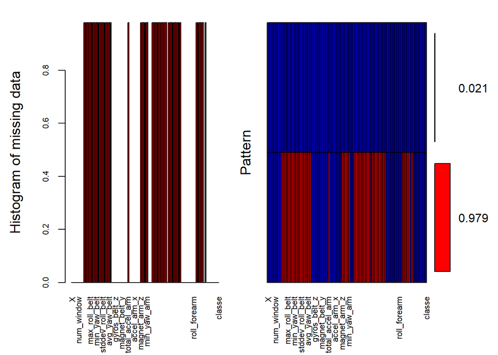

```r
#kable(md.pattern(training))
aggr_plot <- aggr(training, col=c('blue','red'), numbers=TRUE, sortVars=FALSE, labels=names(training), cex.axis=.7, gap=3, ylab=c("Histogram of missing data","Pattern"))
```

From the plot we can read that 98% of data is missing only certain features otherwise for rest of the features there is no NA. So in this case no imputation strategy will be adopted except simply excluding the features having NA.

```r
cols_stat <-apply(training, 2, function (x) sum(is.na(x)))
# keep only columns having no NA
na_cols<- names(cols_stat[cols_stat>0])
training<- training[, !names(training) %in% na_cols]
#we do the same for testing data
testing<- testing[, !names(training) %in% na_cols]
# display first 10 columns with the classe and first 5 observations
kable(head(training[,c(1:10,ncol(training))],5))%>%
  kable_styling(bootstrap_options = "striped", full_width = F)
```

| X | user_name | raw_timestamp_part_1 | raw_timestamp_part_2 | cvtd_timestamp | num_window | roll_belt | pitch_belt | yaw_belt | total_accel_belt | classe |
| --- | --- | --- | --- | --- | --- | --- | --- | --- | --- | --- |
| 1 | carlitos | 1323084231 | 788290 | 05/12/2011 11:23 | 11 | 1.41 | 8.07 | -94.4 | 3 | A |
| 2 | carlitos | 1323084231 | 808298 | 05/12/2011 11:23 | 11 | 1.41 | 8.07 | -94.4 | 3 | A |
| 3 | carlitos | 1323084231 | 820366 | 05/12/2011 11:23 | 11 | 1.42 | 8.07 | -94.4 | 3 | A |
| 4 | carlitos | 1323084232 | 120339 | 05/12/2011 11:23 | 12 | 1.48 | 8.05 | -94.4 | 3 | A |
| 5 | carlitos | 1323084232 | 196328 | 05/12/2011 11:23 | 12 | 1.48 | 8.07 | -94.4 | 3 | A |

### Other cleaning operations

Then remove the identifier column X

```r
# remove the first column which is an id column and plays no  role for prediction
training<- training[,-1]
```

## Cross validation

We partition the data into 2 parts training (70%) and validation (30%)

```r
inTrain <- createDataPartition(training$classe, p=0.7, list = FALSE)
trainData<- training[inTrain, ]
validationData <- training[-inTrain, ]
```